# *Revenue prediction*

## *Scenario*

*You are employed in a bank, present in many countries around the world. It wants to target new potential customers, especially young people of age to open their first bank account. However, it wants to target the prospects most likely to have high incomes later in life. Therefore the team you work with has been tasked creating a model to determine a person's potential income. "What information do we have?" you ask your supervisor who replies: "Actually ... almost none: only the parents' income, because we are going to target the children of our current customers, as well as the country where they live. Oh yes, one last thing: this model must be valid for most countries of the world. With so little data available, it seems like a big challenge! Thus, you propose a linear regression with 3 variables: parents' income, the average income of the country in which the prospect lives, the Gini index calculated on the incomes of the inhabitants of the country in question. Note : This project only deals with the construction and interpretation of the model. You will not go to the prediction stage*

## Skills

- Descriptive statistics
- ANOVA
- Logistic regression
- Inferential statistics
- Basics of probabilities
- Modeling data

**Mission 0 - Data importation**

**Mission 1 - Data cleaning and description**  
a. Income  
b. Population  
c. Gini Index  
d. Summary

**Mission 2 - Data Analysis**  
a. Choice of countries to analyze  
b. Diversity of countries in terms of income distribution  
c. Lorenz Curves  
d. Evolution of the Gini index  
e. Ranking - Gini index

**Mission 3 - Preparation of the final dataframe**

**Mission 4 - Prediction of children's income**  
a. ANOVA: Income of Individuals by Country  
b. Linear Regression 1: Income of Individuals by Average Income and Gini Index  
c. Income of individuals according to the average income of the country, the country's Gini index and the parents' income class  
d. Final model

## Bibliography

- https://stackoverflow.com/questions/2942889/reading-parsing-excel-xls-files-with-python
- http://eric.univ-lyon2.fr/~ricco/cours/didacticiels/Python/cah_kmeans_avec_python.pdf
- https://stackoverflow.com/questions/21660937/get-nearest-point-to-centroid-scikit-learn
- https://datatofish.com/convert-string-to-float-dataframe/
- https://stackoverflow.com/questions/28986489/python-pandas-how-to-replace-a-characters-in-a-column-of-a-dataframe
- https://chrisalbon.com/python/data_wrangling/pandas_dataframe_ranking_rows/
- http://www.datasciencemadesimple.com/repeat-or-replicate-the-dataframe-in-pandas-python/
- https://www.w3schools.com/python/python_json.asp
- https://stackoverflow.com/questions/36390406/pandas-sample-each-group-after-groupby£
- https://statistique-et-logiciel-r.com/anova-a-un-facteur-partie-1/
- https://stackoverflow.com/questions/53205077/how-can-i-dynamically-pass-data-to-the-scipy-stats-levenes-test-function
- https://subscription.packtpub.com/book/big_data_and_business_intelligence/9781787125698/8/ch21lvl1sec78/durbin-watson
- https://statistique-et-logiciel-r.com/regression-lineaire-simple-quand-les-hypotheses-ne-sont-pas-satisfaites/
- https://fr.wikipedia.org/wiki/Diagramme_quantile-quantile
- https://ncss-wpengine.netdna-ssl.com/wp-content/themes/ncss/pdf/Procedures/NCSS/Lag_Plots.pdf
- https://pandas.pydata.org/pandas-docs/stable/user_guide/visualization.html#visualization-lag
- https://machinelearningmastery.com/a-gentle-introduction-to-normality-tests-in-python/
- https://robert-alvarez.github.io/2018-06-04-diagnostic_plots/
- https://docs.scipy.org/doc/scipy/reference/generated/scipy.stats.kurtosis.html
- http://www.educatim.fr/tq/co/Module_TQ_web/co/aplatissement.html
- https://medium.com/@TheDataGyan/day-8-data-transformation-skewness-normalization-and-much-more-4c144d370e55
- https://www.siyavula.com/read/maths/grade-11/statistics/11-statistics-05
- http://mpastell.com/pweave/_downloads/linear_regression.html

## Mission 0 - Data importation

### Importing libraries

```python
import pandas as pd
import matplotlib.pyplot as plt
import numpy as np
import statsmodels.api as sm
import statsmodels.formula.api as smf
```

### Importing data

- revenus 2004-2011 : https://s3-eu-west-1.amazonaws.com/static.oc-static.com/prod/courses/files/parcours-data-analyst/data-projet7.csv
- gini 2004-2018: https://data.worldbank.org/indicator/SI.POV.GINI
- population 2004-2018 : https://databank.banquemondiale.org/data/indicator/SP.POP.TOTL/1ff4a498/Popular-Indicators

```python
income = pd.read_csv("data/data-projet7.csv")
gini = pd.ExcelFile("data/gini.xlsx").parse(0) # parse : numéro de l'onglet du fichier Excel
population = pd.ExcelFile("data/population.xlsx").parse(0)
GDIM = pd.read_csv("data/GDIM_2018.csv")
GDIM = GDIM[['countryname','iso3','region','IGEincome']]
```

## Mission 1 - Data cleaning and description

## a. Income

```python
income.head()
```

|  | country | year_survey | quantile | nb_quantiles | income | gdpppp |
| --- | --- | --- | --- | --- | --- | --- |
| 0 | ALB | 2008 | 1 | 100 | 728,89795 | 7297 |
| 1 | ALB | 2008 | 2 | 100 | 916,66235 | 7297 |
| 2 | ALB | 2008 | 3 | 100 | 1010,916 | 7297 |
| 3 | ALB | 2008 | 4 | 100 | 1086,9078 | 7297 |
| 4 | ALB | 2008 | 5 | 100 | 1132,6997 | 7297 |

### Income et gdpppp

```python
income['income'] = income['income'].str.replace(',', '.')
income['income'] = pd.to_numeric(income['income'], errors='coerce')

income['gdpppp'] = income['gdpppp'].str.replace(',', '.')
income['gdpppp'] = pd.to_numeric(income['gdpppp'], errors='coerce')
```

### Missing Data

```python
# country and year with missing values are found
income[income.isnull().any(axis=1)].drop_duplicates(subset=['country','year_survey'])
```

|  | country | year_survey | quantile | nb_quantiles | income | gdpppp |
| --- | --- | --- | --- | --- | --- | --- |
| 5800 | XKX | 2008 | 1 | 100 | 437.8937 | NaN |
| 11199 | PSE | 2009 | 1 | 100 | 195.2899 | NaN |

```python
# Kosovo is removed since it is not present in any other table.
income = income[income['country']!='XKX']

# For Palestine, the data is imputed.
income.loc[income['country'] == 'PSE','gdpppp'] = 1356
```

*Source : https://fr.tradingeconomics.com/palestine/gdp-per-capita*

### Unusual / aberrant values

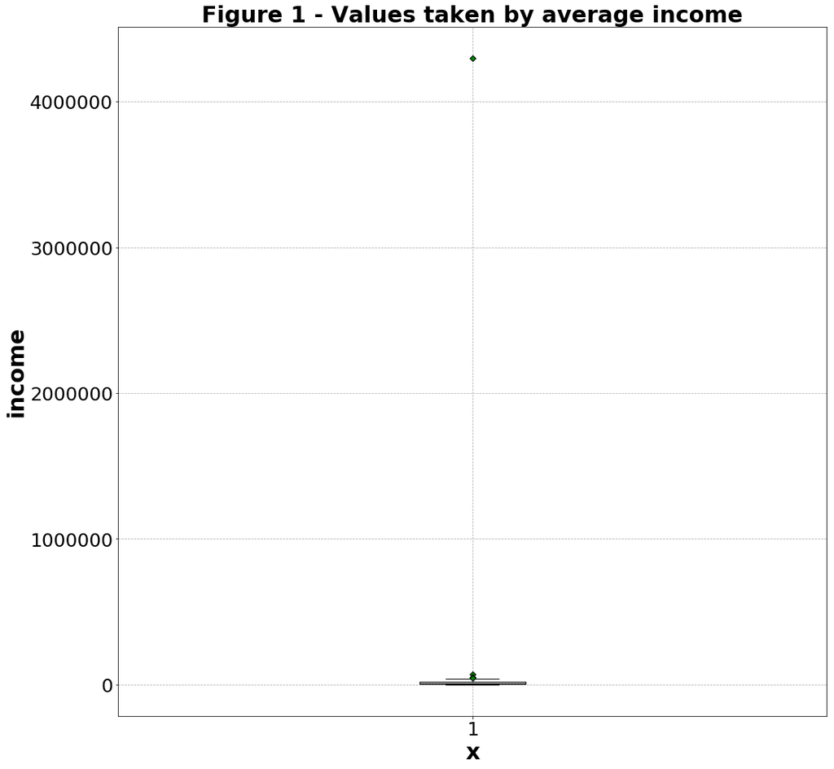

```python
# Plotting Figure
medianprops = {'color':"black"}
green_diamond = dict(markerfacecolor='g', marker='D')
plt.figure(figsize = (17, 17))
plt.boxplot(income['gdpppp'].drop_duplicates(), medianprops=medianprops, vert=True,flierprops=green_diamond)
plt.xlabel('x',fontsize=30,fontweight = 'bold')
plt.ylabel('income',fontsize=30,fontweight = 'bold')
plt.xticks(fontsize=25)
plt.yticks(fontsize=25)
plt.grid(True,linestyle='--')
plt.title('Figure 1 - Values taken by average income',fontsize=30,fontweight = 'bold')
plt.savefig('figure/Figure 1 - Values taken by average income.png', dpi=300)
plt.show()
plt.close()
```

There is an aberrant value for average income.

```python
income.sort_values(by='gdpppp', ascending=False).head(3)
```

|  | country | year_survey | quantile | nb_quantiles | income | gdpppp |
| --- | --- | --- | --- | --- | --- | --- |
| 3297 | FJI | 2008 | 98 | 100 | 7265.1255 | 4300332.0 |
| 3272 | FJI | 2008 | 73 | 100 | 2210.0690 | 4300332.0 |
| 3270 | FJI | 2008 | 71 | 100 | 2104.9932 | 4300332.0 |

A GDP per capita (PPP) of 4,300,332 for Fiji is anormal.

According to the website https://www.tradingeconomics.com/fiji/gdp-per-capita-ppp, the GDP per capita (PPP) is: 7384 (PPP). This data is imputed.

```python
income.loc[income['country'] == 'FJI','gdpppp'] = 7384
```

### For each country, we look if there are 100 distinct quantile numbers less than or equal to 100

```python
country = income.groupby(["country"])["country"].first()
count_quantile = income[income["quantile"] <= 100].drop_duplicates(subset=['country','quantile']).groupby(["country"])["quantile"].count()
count_quantile =  pd.DataFrame([a for a in zip(country,count_quantile)])
count_quantile.columns = ["country","count"]
count_quantile[count_quantile['count'] != 100]
```

|  | country | count |
| --- | --- | --- |
| 62 | LTU | 99 |

```python
for i in range(1,101):
    if i not in income.loc[income['country'] == 'LTU','quantile'].values:
        print("Quantile",i,"is not present.")
```

```
Quantile 41 is not present.
```

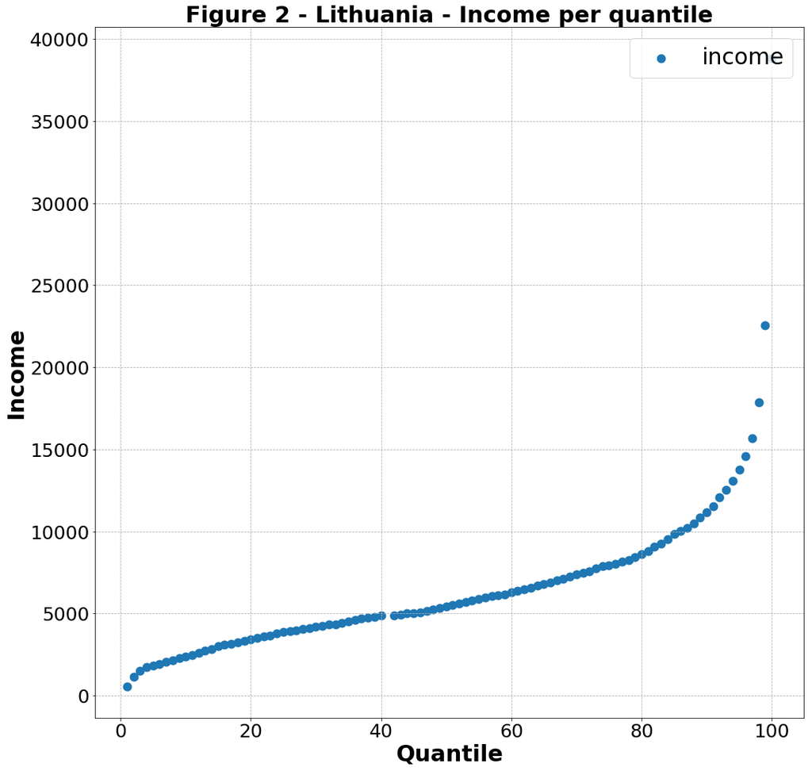

```python
# For LTU
ltu = income[income['country'] == 'LTU']

# Plotting Figure
plt.figure(figsize = (17, 17))
plt.scatter(ltu['quantile'], ltu['income'],linewidth=6)
plt.xlabel('Quantile',fontsize=30,fontweight = 'bold')
plt.ylabel('Income',fontsize=30,fontweight = 'bold')
plt.xticks(fontsize=25)
plt.yticks(fontsize=25)
plt.grid(True,linestyle='--')
plt.legend(loc='upper right',fontsize=30)
plt.title('Figure 2 - Lithuania - Income per quantile',fontsize=30,fontweight = 'bold')
plt.savefig('figure/Figure 2 - Lithuania - Income per quantile.png', dpi=300)
plt.show()
plt.close()
```

Quantile 41 is not mentioned for Lithuania.

Given the distribution of income by quantile, the income of quantile 41 is imputed by the value 5000 (PPP)

```python
# Data imputation
imputation = pd.DataFrame([['LTU',2008,41,100,5000,17571]], columns=['country','year_survey','quantile','nb_quantiles','income','gdpppp'])
income = income.append(imputation,ignore_index=True)
```

### b. Population

```python
# Rename column
population.columns = ['year', 'year_code','country_name','country_code','population']

# Missing data are removed
population = population.dropna(axis = 0, how = 'any')
population.head()
```

|  | year | year_code | country_name | country_code | population |
| --- | --- | --- | --- | --- | --- |
| 0 | 2004 | YR2004 | Afghanistan | AFG | 24118979.0 |
| 1 | 2004 | YR2004 | Albania | ALB | 3026939.0 |
| 2 | 2004 | YR2004 | Algeria | DZA | 32831096.0 |
| 3 | 2004 | YR2004 | American Samoa | ASM | 59264.0 |
| 4 | 2004 | YR2004 | Andorra | AND | 76244.0 |

```python
# A left join is made between the revenue and population table on the key [country, year]
data = income.merge(population, how = 'left', left_on=['country','year_survey'], right_on = ['country_code','year'])
data = data[['country','year_survey','quantile','nb_quantiles','income','gdpppp','population']]
data.head()
```

|  | country | year_survey | quantile | nb_quantiles | income | gdpppp | population |
| --- | --- | --- | --- | --- | --- | --- | --- |
| 0 | ALB | 2008 | 1 | 100 | 728.89795 | 7297.0 | 2947314.0 |
| 1 | ALB | 2008 | 2 | 100 | 916.66235 | 7297.0 | 2947314.0 |
| 2 | ALB | 2008 | 3 | 100 | 1010.91600 | 7297.0 | 2947314.0 |
| 3 | ALB | 2008 | 4 | 100 | 1086.90780 | 7297.0 | 2947314.0 |
| 4 | ALB | 2008 | 5 | 100 | 1132.69970 | 7297.0 | 2947314.0 |

```python
country_population = data[['country','population']].drop_duplicates()
country_population[country_population.isnull().any(axis=1)]
```

|  | country | population |
| --- | --- | --- |
| 10299 | TWN | NaN |

```python
income[income['country']=='TWN']['year_survey'].drop_duplicates()
```

```
10299    2008
Name: year_survey, dtype: int64
```

The population for Taiwan in 2008 is missing.

We impute with data found online: 22800000 inhabitants https://www.worldometers.info/world-population/taiwan-population/

```python
data.loc[data['country'] == 'TWN','population'] = 22800000
```

### c. Gini Index

```python
# Rename : columns
gini.columns = ['year', 'year_code','country_name','country_code','indice_gini']

# Missing data are removed
gini = gini.dropna(axis = 0, how = 'any')
gini.head()
```

|  | year | year_code | country_name | country_code | indice_gini |
| --- | --- | --- | --- | --- | --- |
| 7 | 2004 | YR2004 | Argentina | ARG | 48.3 |
| 8 | 2004 | YR2004 | Armenia | ARM | 37.5 |
| 10 | 2004 | YR2004 | Australia | AUS | 33.1 |
| 11 | 2004 | YR2004 | Austria | AUT | 29.8 |
| 12 | 2004 | YR2004 | Azerbaijan | AZE | 26.6 |

```python
# A left join is made between the data and gini table on the key [country, year]
data = data.merge(gini, how = 'left', left_on=['country','year_survey'], right_on = ['country_code','year'])
data = data[['country','year_survey','quantile','nb_quantiles','income','gdpppp','population','country_name','indice_gini']]
data.head()
```

|  | country | year_survey | quantile | nb_quantiles | income | gdpppp | population | country_name | indice_gini |
| --- | --- | --- | --- | --- | --- | --- | --- | --- | --- |
| 0 | ALB | 2008 | 1 | 100 | 728.89795 | 7297.0 | 2947314.0 | Albania | 30.0 |
| 1 | ALB | 2008 | 2 | 100 | 916.66235 | 7297.0 | 2947314.0 | Albania | 30.0 |
| 2 | ALB | 2008 | 3 | 100 | 1010.91600 | 7297.0 | 2947314.0 | Albania | 30.0 |
| 3 | ALB | 2008 | 4 | 100 | 1086.90780 | 7297.0 | 2947314.0 | Albania | 30.0 |
| 4 | ALB | 2008 | 5 | 100 | 1132.69970 | 7297.0 | 2947314.0 | Albania | 30.0 |

```python
missing_data = data[data.isnull().any(axis=1)].drop_duplicates(subset=['country','year_survey'])
missing_data
```

|  | country | year_survey | quantile | nb_quantiles | income | gdpppp | population | country_name | indice_gini |
| --- | --- | --- | --- | --- | --- | --- | --- | --- | --- |
| 400 | AZE | 2008 | 1 | 100 | 397.539830 | 8101.00000 | 8.763400e+06 | NaN | NaN |
| 1500 | CAN | 2008 | 1 | 100 | 122.424810 | 35895.00000 | 3.324577e+07 | NaN | NaN |
| 1700 | CHN | 2007 | 1 | 100 | 16.719418 | 5712.00000 | 1.317885e+09 | NaN | NaN |
| 2800 | EGY | 2009 | 1 | 100 | 458.958400 | 5011.00000 | 8.246502e+07 | NaN | NaN |
| 3600 | GHA | 2006 | 1 | 100 | 63.157047 | 1380.11820 | 2.211342e+07 | NaN | NaN |
| 3900 | GTM | 2011 | 1 | 100 | 38.463615 | 4367.00000 | 1.494892e+07 | NaN | NaN |
| 4100 | HRV | 2008 | 1 | 100 | 1355.107300 | 17219.00000 | 4.309705e+06 | NaN | NaN |
| 4400 | IND | 2007 | 1 | 100 | 247.838730 | 2796.00000 | 1.179681e+09 | NaN | NaN |
| 4600 | IRN | 2008 | 1 | 100 | 441.563080 | 10446.00000 | 7.284554e+07 | NaN | NaN |
| 4700 | IRQ | 2008 | 1 | 100 | 185.814540 | 3171.00000 | 2.911142e+07 | NaN | NaN |
| 4900 | ISR | 2008 | 1 | 100 | 142.350430 | 25740.00000 | 7.308800e+06 | NaN | NaN |
| 5400 | KEN | 2007 | 1 | 100 | 96.683630 | 1429.00000 | 3.808591e+07 | NaN | NaN |
| 5600 | KHM | 2008 | 1 | 100 | 345.874970 | 1802.00000 | 1.388051e+07 | NaN | NaN |
| 6000 | LKA | 2007 | 1 | 100 | 363.082950 | 4202.57030 | 1.981079e+07 | NaN | NaN |
| 6399 | MAR | 2007 | 1 | 100 | 353.848900 | 3973.00000 | 3.122588e+07 | NaN | NaN |
| 6799 | MKD | 2008 | 1 | 100 | 559.179600 | 8809.00000 | 2.067378e+06 | NaN | NaN |
| 6899 | MLI | 2010 | 1 | 100 | 122.693474 | 929.52966 | 1.507508e+07 | NaN | NaN |
| 7499 | MYS | 2009 | 1 | 100 | 589.087600 | 13163.00000 | 2.760538e+07 | NaN | NaN |
| 7699 | NGA | 2010 | 1 | 100 | 51.049760 | 1946.00000 | 1.585783e+08 | NaN | NaN |
| 8199 | PAK | 2008 | 1 | 100 | 275.189820 | 2335.00000 | 1.636446e+08 | NaN | NaN |
| 10299 | TWN | 2008 | 1 | 100 | 3477.180000 | 25342.00000 | 2.280000e+07 | NaN | NaN |
| 10799 | USA | 2008 | 1 | 100 | 663.476100 | 43261.00000 | 3.040940e+08 | NaN | NaN |
| 11199 | YEM | 2008 | 1 | 100 | 162.951310 | 2224.00000 | 2.235639e+07 | NaN | NaN |
| 11399 | COD | 2008 | 1 | 100 | 29.364283 | 303.19305 | 6.037361e+07 | NaN | NaN |

```python
countries_missing_data = list(missing_data['country'])
```

### Imputation of country names

```python
country_code = GDIM[['countryname','iso3']].drop_duplicates()
country_code.head()
```

|  | countryname | iso3 |
| --- | --- | --- |
| 0 | Afghanistan | AFG |
| 12 | Angola | AGO |
| 24 | Albania | ALB |
| 84 | Argentina | ARG |
| 99 | Armenia | ARM |

```python
for code in countries_missing_data :
    data.loc[data['country'] == code,'country_name'] = list(country_code.loc[country_code['iso3'] == code,'countryname'])
```

```python
missing_data = data[data.isnull().any(axis=1)].drop_duplicates(subset=['country','year_survey'])
missing_data
```

|  | country | year_survey | quantile | nb_quantiles | income | gdpppp | population | country_name | indice_gini |
| --- | --- | --- | --- | --- | --- | --- | --- | --- | --- |
| 400 | AZE | 2008 | 1 | 100 | 397.539830 | 8101.00000 | 8.763400e+06 | Azerbaijan | NaN |
| 1500 | CAN | 2008 | 1 | 100 | 122.424810 | 35895.00000 | 3.324577e+07 | Canada | NaN |
| 1700 | CHN | 2007 | 1 | 100 | 16.719418 | 5712.00000 | 1.317885e+09 | China | NaN |
| 2800 | EGY | 2009 | 1 | 100 | 458.958400 | 5011.00000 | 8.246502e+07 | Egypt, Arab Rep. | NaN |
| 3600 | GHA | 2006 | 1 | 100 | 63.157047 | 1380.11820 | 2.211342e+07 | Ghana | NaN |
| 3900 | GTM | 2011 | 1 | 100 | 38.463615 | 4367.00000 | 1.494892e+07 | Guatemala | NaN |
| 4100 | HRV | 2008 | 1 | 100 | 1355.107300 | 17219.00000 | 4.309705e+06 | Croatia | NaN |
| 4400 | IND | 2007 | 1 | 100 | 247.838730 | 2796.00000 | 1.179681e+09 | India | NaN |
| 4600 | IRN | 2008 | 1 | 100 | 441.563080 | 10446.00000 | 7.284554e+07 | Iran, Islamic Rep. | NaN |
| 4700 | IRQ | 2008 | 1 | 100 | 185.814540 | 3171.00000 | 2.911142e+07 | Iraq | NaN |
| 4900 | ISR | 2008 | 1 | 100 | 142.350430 | 25740.00000 | 7.308800e+06 | Israel | NaN |
| 5400 | KEN | 2007 | 1 | 100 | 96.683630 | 1429.00000 | 3.808591e+07 | Kenya | NaN |
| 5600 | KHM | 2008 | 1 | 100 | 345.874970 | 1802.00000 | 1.388051e+07 | Cambodia | NaN |
| 6000 | LKA | 2007 | 1 | 100 | 363.082950 | 4202.57030 | 1.981079e+07 | Sri Lanka | NaN |
| 6399 | MAR | 2007 | 1 | 100 | 353.848900 | 3973.00000 | 3.122588e+07 | Morocco | NaN |
| 6799 | MKD | 2008 | 1 | 100 | 559.179600 | 8809.00000 | 2.067378e+06 | Macedonia, FYR | NaN |
| 6899 | MLI | 2010 | 1 | 100 | 122.693474 | 929.52966 | 1.507508e+07 | Mali | NaN |
| 7499 | MYS | 2009 | 1 | 100 | 589.087600 | 13163.00000 | 2.760538e+07 | Malaysia | NaN |
| 7699 | NGA | 2010 | 1 | 100 | 51.049760 | 1946.00000 | 1.585783e+08 | Nigeria | NaN |
| 8199 | PAK | 2008 | 1 | 100 | 275.189820 | 2335.00000 | 1.636446e+08 | Pakistan | NaN |
| 10299 | TWN | 2008 | 1 | 100 | 3477.180000 | 25342.00000 | 2.280000e+07 | Taiwan, China | NaN |
| 10799 | USA | 2008 | 1 | 100 | 663.476100 | 43261.00000 | 3.040940e+08 | United States | NaN |
| 11199 | YEM | 2008 | 1 | 100 | 162.951310 | 2224.00000 | 2.235639e+07 | Yemen, Rep. | NaN |
| 11399 | COD | 2008 | 1 | 100 | 29.364283 | 303.19305 | 6.037361e+07 | Congo, Dem. Rep. | NaN |

### Imputation of Gini indexes

From the income of each quantile, we compute the Gini index for the countries whose Gini index is missing. The Gini index of a country is twice the area between the curve of the "perfectly egalitarian case" and the Lorenz curve associated with the country.

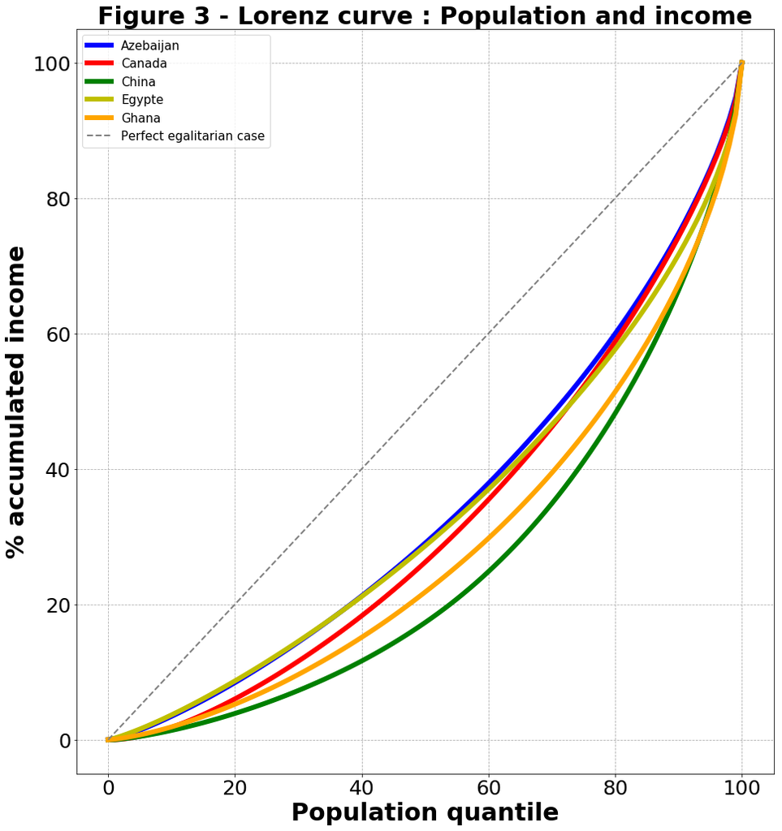

```python
country_code_to_imput_gini = ['AZE','CAN','CHN','EGY','GHA']
country_name_to_imput_gini = ['Azebaijan','Canada','China','Egypte','Ghana']
color = ['b','r','g','y','orange','black','grey','brown','purple','pink']

# Plotting Figure
plt.figure(figsize = (15.5, 17))
for country_code,country_name, c in zip(country_code_to_imput_gini, country_name_to_imput_gini, color):
    # income_2008_total_country : Total revenue on the 100 percentiles
    income_total_country = data[data.country==country_code]['income'].sum()
    # lorenz : Lorenz curve
    lorenz = (np.cumsum(np.sort(data[data.country==country_code]['income']))/income_total_country)*100
    lorenz = np.append([0],lorenz)
    x = np.append([0],data[data.country==country_code]['quantile'])
    plt.plot(x,lorenz,c,linewidth=6, label=country_name)

plt.plot([0,100],[0,100],'grey',linestyle='--',linewidth=2, label='Perfect egalitarian case')
plt.xlabel('Population quantile',fontsize=30,fontweight = 'bold')
plt.ylabel('% accumulated income',fontsize=30,fontweight = 'bold')
plt.xticks(fontsize=25)
plt.yticks(fontsize=25)
plt.legend(loc='upper left',fontsize=15)
plt.grid(True,linestyle='--')
plt.title('Figure 3 - Lorenz curve : Population and income',fontsize=30,fontweight = 'bold')
plt.savefig('figure/Figure 3 - Lorenz curve : Population and income.png', dpi=300)
plt.show()
```

```python
# calculation of Gini indices for each country whose index is missing
list_gini = []
for country_code in countries_missing_data:
    # income_2008_total_country : Total revenue on the 100 percentiles
    income_total_country = data[data.country==country_code]['income'].sum()
    # lorenz : Lorenz curve
    lorenz = (np.cumsum(np.sort(income[income.country==country_code]['income']))/income_total_country)*100
    lorenz = np.append([0],lorenz) # La courbe de Lorenz commence à 0

    aire_ss_courbe = lorenz[:-1].sum()/len(lorenz)
    S = 50 - aire_ss_courbe
    value_gini = 2*S
    list_gini.append(round(value_gini,2))
```

```python
missing_data.loc[:,'indice_gini'] = list_gini
missing_data
```

|  | country | year_survey | quantile | nb_quantiles | income | gdpppp | population | country_name | indice_gini |
| --- | --- | --- | --- | --- | --- | --- | --- | --- | --- |
| 400 | AZE | 2008 | 1 | 100 | 397.539830 | 8101.00000 | 8.763400e+06 | Azerbaijan | 32.90 |
| 1500 | CAN | 2008 | 1 | 100 | 122.424810 | 35895.00000 | 3.324577e+07 | Canada | 36.66 |
| 1700 | CHN | 2007 | 1 | 100 | 16.719418 | 5712.00000 | 1.317885e+09 | China | 49.33 |
| 2800 | EGY | 2009 | 1 | 100 | 458.958400 | 5011.00000 | 8.246502e+07 | Egypt, Arab Rep. | 34.71 |
| 3600 | GHA | 2006 | 1 | 100 | 63.157047 | 1380.11820 | 2.211342e+07 | Ghana | 44.32 |
| 3900 | GTM | 2011 | 1 | 100 | 38.463615 | 4367.00000 | 1.494892e+07 | Guatemala | 58.25 |
| 4100 | HRV | 2008 | 1 | 100 | 1355.107300 | 17219.00000 | 4.309705e+06 | Croatia | 31.96 |
| 4400 | IND | 2007 | 1 | 100 | 247.838730 | 2796.00000 | 1.179681e+09 | India | 35.11 |
| 4600 | IRN | 2008 | 1 | 100 | 441.563080 | 10446.00000 | 7.284554e+07 | Iran, Islamic Rep. | 44.99 |
| 4700 | IRQ | 2008 | 1 | 100 | 185.814540 | 3171.00000 | 2.911142e+07 | Iraq | 37.63 |
| 4900 | ISR | 2008 | 1 | 100 | 142.350430 | 25740.00000 | 7.308800e+06 | Israel | 42.99 |
| 5400 | KEN | 2007 | 1 | 100 | 96.683630 | 1429.00000 | 3.808591e+07 | Kenya | 31.58 |
| 5600 | KHM | 2008 | 1 | 100 | 345.874970 | 1802.00000 | 1.388051e+07 | Cambodia | 33.04 |
| 6000 | LKA | 2007 | 1 | 100 | 363.082950 | 4202.57030 | 1.981079e+07 | Sri Lanka | 41.80 |
| 6399 | MAR | 2007 | 1 | 100 | 353.848900 | 3973.00000 | 3.122588e+07 | Morocco | 42.30 |
| 6799 | MKD | 2008 | 1 | 100 | 559.179600 | 8809.00000 | 2.067378e+06 | Macedonia, FYR | 41.09 |
| 6899 | MLI | 2010 | 1 | 100 | 122.693474 | 929.52966 | 1.507508e+07 | Mali | 34.68 |
| 7499 | MYS | 2009 | 1 | 100 | 589.087600 | 13163.00000 | 2.760538e+07 | Malaysia | 48.33 |
| 7699 | NGA | 2010 | 1 | 100 | 51.049760 | 1946.00000 | 1.585783e+08 | Nigeria | 48.34 |
| 8199 | PAK | 2008 | 1 | 100 | 275.189820 | 2335.00000 | 1.636446e+08 | Pakistan | 31.68 |
| 10299 | TWN | 2008 | 1 | 100 | 3477.180000 | 25342.00000 | 2.280000e+07 | Taiwan, China | 33.15 |
| 10799 | USA | 2008 | 1 | 100 | 663.476100 | 43261.00000 | 3.040940e+08 | United States | 44.73 |
| 11199 | YEM | 2008 | 1 | 100 | 162.951310 | 2224.00000 | 2.235639e+07 | Yemen, Rep. | 39.03 |
| 11399 | COD | 2008 | 1 | 100 | 29.364283 | 303.19305 | 6.037361e+07 | Congo, Dem. Rep. | 45.94 |

```python
for code in countries_missing_data :
    data.loc[data['country'] == code,'indice_gini'] = list(missing_data.loc[missing_data['country'] == code,'indice_gini'])
```

```python
data[data.isnull().any(axis=1)].drop_duplicates(subset=['country','year_survey'])
```

|  | country | year_survey | quantile | nb_quantiles | income | gdpppp | population | country_name | indice_gini |
| --- | --- | --- | --- | --- | --- | --- | --- | --- | --- |

## d. Summary

### Year (s) of data used

```python
list(data['year_survey'].drop_duplicates().sort_values())
```

```
[2004, 2006, 2007, 2008, 2009, 2010, 2011]
```

### Number of countries present

```python
# number of countries per year
data.groupby('year_survey').country.nunique()
```

```
year_survey
2004     1
2006     5
2007    15
2008    75
2009    12
2010     6
2011     1
Name: country, dtype: int64
```

```python
nb_countries = len(data['country'].drop_duplicates())
print('The analysis concerns',nb_countries,'countries.')
```

```
The analysis concerns 115 countries.
```

### Population represented (compared to 2008)

```python
# Since most of the data come from 2008 (75 countries), the population represented is compared to that of 2008
population_2008 = population[population['year']==2008].population.sum()
population_concerned = data[['country','population']].drop_duplicates().population.sum()
print('The population covered by the analysis represents',round(100*population_concerned/population_2008,2),'% of the world population.')
```

```
The population covered by the analysis represents 91.86 % of the world population.
```

## Mission 2 - Data Analysis

## a. Choice of countries to analyze

115 countries are present in Data. To analyze the data from an economic point of view, 5 to 10 countries are chosen from all countries. To select these 5 to 10 representative countries from all the countries, a clustering of 115 countries is carried out on the two "economic" variables: the average income of the country and the Gini index of the country.

### Data: Contains Gini index, gdpppp, population by country

```python
data.head()
```

|  | country | year_survey | quantile | nb_quantiles | income | gdpppp | population | country_name | indice_gini |
| --- | --- | --- | --- | --- | --- | --- | --- | --- | --- |
| 0 | ALB | 2008 | 1 | 100 | 728.89795 | 7297.0 | 2947314.0 | Albania | 30.0 |
| 1 | ALB | 2008 | 2 | 100 | 916.66235 | 7297.0 | 2947314.0 | Albania | 30.0 |
| 2 | ALB | 2008 | 3 | 100 | 1010.91600 | 7297.0 | 2947314.0 | Albania | 30.0 |
| 3 | ALB | 2008 | 4 | 100 | 1086.90780 | 7297.0 | 2947314.0 | Albania | 30.0 |
| 4 | ALB | 2008 | 5 | 100 | 1132.69970 | 7297.0 | 2947314.0 | Albania | 30.0 |

```python
data_clust = data[['country_name','gdpppp','indice_gini']].drop_duplicates()

# Lines where there is at least one NA are removed.
data_clust = data_clust.dropna(axis=0, how='any')

data_clust_copie = data_clust.copy()

# Country names become the indexes of the dataFrame
data_clust_copie = data_clust_copie.set_index('country_name')
data_clust_copie.head()
```

| country_name | gdpppp | indice_gini |
| --- | --- | --- |
| Albania | 7297.0 | 30.0 |
| Argentina | 13220.0 | 44.5 |
| Armenia | 5611.0 | 29.2 |
| Austria | 36193.0 | 30.4 |
| Azerbaijan | 8101.0 | 32.9 |

```python
data_clust.shape
```

```
(115, 3)
```

```python
from sklearn import preprocessing

# data preparation for clustering
X = data_clust_copie.values
X_scaled = preprocessing.StandardScaler().fit_transform(X)
```

```
[0.46640384 0.48087162 0.40853289 0.38824825 0.40021603 0.40238203
 0.42332575 0.40284662 0.424409  ]
```

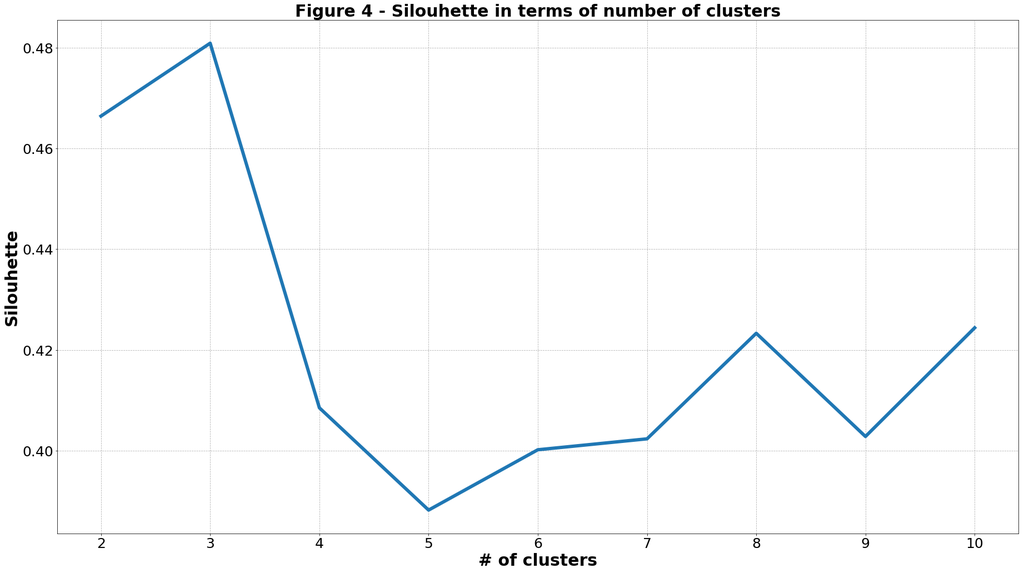

```python
#library for evaluating partitions
from sklearn import metrics
from sklearn import cluster

import random
random.seed(1092)
#use of the "silhouette" metric
#make the number of clusters from 2 to 10
res = np.arange(9,dtype="double")
for k in np.arange(9):
    km = cluster.KMeans(n_clusters=k+2)
    km.fit(X_scaled)
    res[k] = metrics.silhouette_score(X_scaled,km.labels_)
print(res)

# Plotting figure
plt.figure(figsize = (31, 17))
plt.plot(np.arange(2,11,1),res, linewidth = 6)
plt.xlabel("# of clusters",fontsize=30,fontweight = 'bold')
plt.ylabel("Silouhette",fontsize=30,fontweight = 'bold')
plt.xticks(fontsize=25)
plt.yticks(fontsize=25)
plt.grid(True,linestyle='--')
plt.title('Figure 4 - Silouhette in terms of number of clusters',fontsize=30,fontweight = 'bold')
plt.savefig('figure/Figure 4 - Silouhette in terms of number of clusters.png', dpi=300)
plt.show()
plt.close()
```

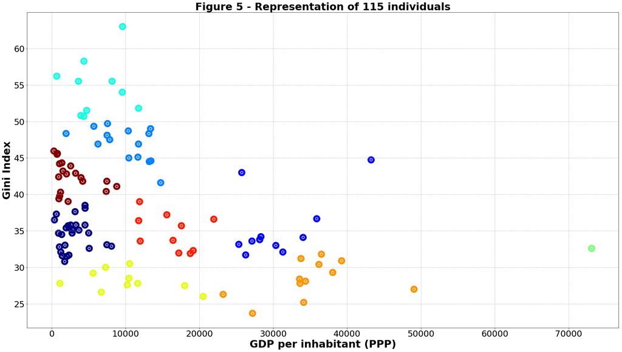

```python
from sklearn.cluster import KMeans
from sklearn import decomposition

# Desired number of clusters
n_clust = 9

# Clustering par K-means
km = KMeans(n_clusters=n_clust)
km.fit(X_scaled)

# clusters attributed to each individual
clusters = km.labels_

# Plotting figure
plt.figure(figsize = (31, 17))
plt.scatter(data_clust.gdpppp, data_clust.indice_gini, c=clusters.astype(np.float), cmap = 'jet',linewidth=15)
plt.xlabel('GDP per inhabitant (PPP)',fontsize=30,fontweight = 'bold')
plt.ylabel('Gini Index',fontsize=30,fontweight = 'bold')
plt.xticks(fontsize=25)
plt.yticks(fontsize=25)
plt.grid(True,linestyle='--')
plt.title("Figure 5 - Representation of {} individuals".format(data_clust.shape[0]),fontsize=30,fontweight = 'bold')
plt.savefig('figure/Figure 5 - Representation of {} individuals.png', dpi=300)
plt.show()
plt.close()
```

```python
data_clust.loc[:,'clusters'] = clusters.tolist()
data_clust.head()
```

|  | country_name | gdpppp | indice_gini | clusters |
| --- | --- | --- | --- | --- |
| 0 | Albania | 7297.0 | 30.0 | 5 |
| 100 | Argentina | 13220.0 | 44.5 | 2 |
| 200 | Armenia | 5611.0 | 29.2 | 5 |
| 300 | Austria | 36193.0 | 30.4 | 6 |
| 400 | Azerbaijan | 8101.0 | 32.9 | 0 |

```python
#average per variable
m = data_clust.mean()
#data.frame conditionally to groups
gb = data_clust.groupby(km.labels_)
nk = gb.size()
print(nk)
mk = gb.mean()
print(mk)
```

```
0    27
1    11
2    15
3    10
4     1
5    10
6    12
7    10
8    19
dtype: int64
         gdpppp  indice_gini  clusters
0   2925.179982    34.549259         0
1  30532.000000    35.457273         1
2   9938.800000    46.906000         2
3   6083.800000    54.725000         3
4  73127.000000    32.600000         4
5  10217.113220    28.150000         5
6  34915.750000    28.341667         6
7  16239.200000    34.836000         7
8   2730.326686    42.456842         8
```

### Country selection

```python
for i in range(n_clust):
    print('Cluster ',i)
    print(list(data_clust[data_clust['clusters']==i]['country_name']))
```

[output not shown]

The country with the highest Gini index and the country with the lowest Gini index are selected.

```python
data_clust.sort_values(by='indice_gini', ascending = False).iloc[[0,-1],]
```

|  | country_name | gdpppp | indice_gini | clusters |
| --- | --- | --- | --- | --- |
| 11299 | South Africa | 9602.0 | 63.0 | 3 |
| 9499 | Slovenia | 27197.0 | 23.7 | 6 |

In addition, an "interpretable" country per cluster is chosen.

```python
country_chosen_code = ['SVN','UKR','LUX','FRA','VNM','PRT','RUS','PAN','ZAF']
country_chosen_name = ['Slovenia','Ukraine','Luxembourg','France','Vietnam','Portugal','Russian Federation','Panama','South Africa']
color = ['b','r','g','y','orange','black','grey','brown','purple']
```

```python
data_clust[data_clust['country_name'].isin(country_chosen_name)].sort_values(by='indice_gini', ascending=True)
```

|  | country_name | gdpppp | indice_gini | clusters |
| --- | --- | --- | --- | --- |
| 9499 | Slovenia | 27197.0 | 23.7 | 6 |
| 10599 | Ukraine | 6721.0 | 26.6 | 5 |
| 6199 | Luxembourg | 73127.0 | 32.6 | 4 |
| 3300 | France | 30357.0 | 33.0 | 1 |
| 10999 | Vietnam | 2578.0 | 35.8 | 0 |
| 8699 | Portugal | 21956.0 | 36.6 | 7 |
| 8999 | Russian Federation | 14766.0 | 41.6 | 2 |
| 8299 | Panama | 11767.0 | 51.8 | 3 |
| 11299 | South Africa | 9602.0 | 63.0 | 3 |

## b. Diversity of countries in terms of income distribution

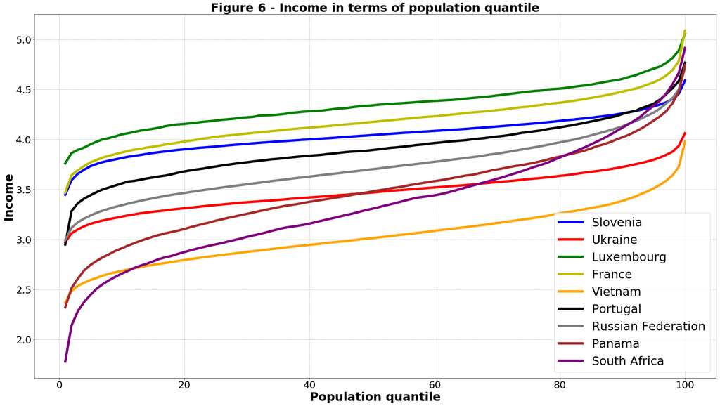

```python
# Plotting figure
plt.figure(figsize = (31, 17))
for country_code,country_name, c in zip(country_chosen_code, country_chosen_name, color):
    plt.plot(data[data.country==country_code]['quantile'], np.log10(data[data.country==country_code]['income']), c , label=country_name,linewidth=6)
plt.xlabel('Population quantile',fontsize=30,fontweight = 'bold')
plt.ylabel('Income',fontsize=30,fontweight = 'bold')
plt.xticks(fontsize=25)
plt.yticks(fontsize=25)
plt.legend(loc='lower right',fontsize=30)
plt.grid(True,linestyle='--')
plt.title('Figure 6 - Income in terms of population quantile',fontsize=30,fontweight = 'bold')
plt.savefig('figure/Figure 6 - Income in terms of population quantile.png', dpi=300)
plt.show()
plt.close()
```

### Interpretation

The Luxembourgers belonging to a defined percentile are richer than the citizens of other countries belonging to the same n ° of the percentile.

The same can be said for France which is here, richer than other countries in terms of revenue per quantile.

Slovenia has the lowest Gini index. Thus, it is the country for which the distribution of wealth within the population is the least unequal. The weak slope of the curve representing Slovenia confirms it.

On the contrary, South Africa has the strongest Gini index. Thus, it is the country for which the distribution of wealth within the population is the most unequal. The sharp slope of the curve representing South Africa confirms it.

## c. Lorenz curves

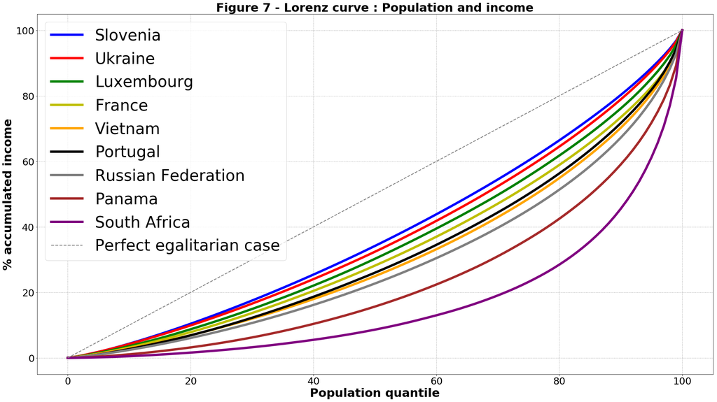

```python
# Plotting figure
plt.figure(figsize = (31, 17))
for country_code,country_name, c in zip(country_chosen_code, country_chosen_name, color):
    # income_2008_total_country : Total revenue on the 100 percentiles
    income_total_country = data[data.country==country_code]['income'].sum()
    # lorenz : Lorenz curve
    lorenz = (np.cumsum(np.sort(data[data.country==country_code]['income']))/income_total_country)*100
    lorenz = np.append([0],lorenz)
    x = np.append([0],data[data.country==country_code]['quantile'])
    plt.plot(x,lorenz,c,linewidth=6, label=country_name)

plt.plot([0,100],[0,100],'grey',linestyle='--',linewidth=2, label='Perfect egalitarian case')
plt.xlabel('Population quantile',fontsize=30,fontweight = 'bold')
plt.ylabel('% accumulated income',fontsize=30,fontweight = 'bold')
plt.xticks(fontsize=25)
plt.yticks(fontsize=25)
plt.legend(loc='upper left',fontsize=40)
plt.grid(True,linestyle='--')
plt.title('Figure 7 - Lorenz curve : Population and income',fontsize=30,fontweight = 'bold')
plt.savefig('figure/Figure 7 - Lorenz curve : Population and income.png', dpi=300)
plt.show()
```

## d. Gini index evolution

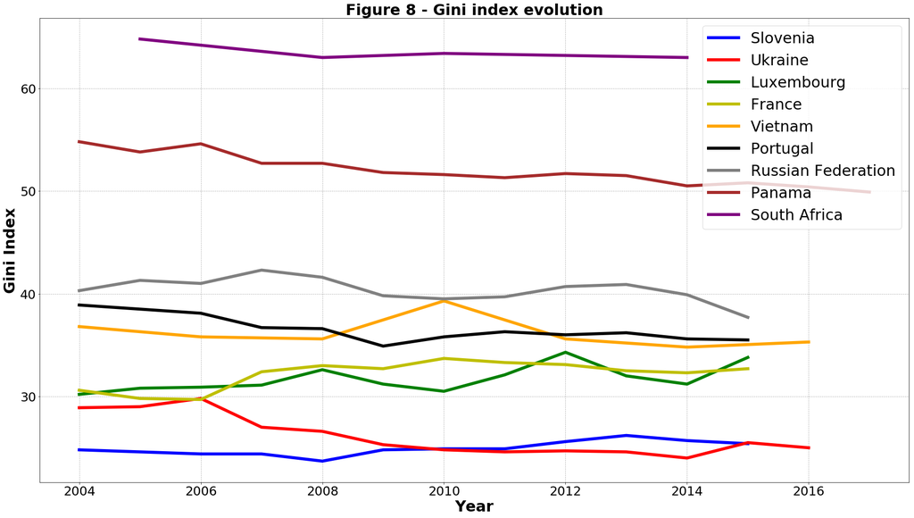

```python
# Plotting figure
plt.figure(figsize = (31, 17))
for country_code,country_name, c in zip(country_chosen_code, country_chosen_name, color):
    plt.plot(gini[gini.country_code==country_code]['year'],gini[gini.country_code==country_code]['indice_gini'],c,linewidth=6, label=country_name)
plt.xlabel('Year',fontsize=30,fontweight = 'bold')
plt.ylabel('Gini Index',fontsize=30,fontweight = 'bold')
plt.xticks(fontsize=25)
plt.yticks(fontsize=25)
plt.legend(loc='upper right',fontsize=30)
plt.grid(True,linestyle='--')
plt.title('Figure 8 - Gini index evolution',fontsize=30,fontweight = 'bold')
plt.savefig('figure/Figure 8 - Gini index evolution.png', dpi=300)
plt.show()
```

### Interpretation

Some data is missing. This is not a problem because we only look at the trend over the period 2004-2016.

For Panama and Ukraine, the Gini index has declined over time: the distribution of wealth has become more egalitarian.

For the other countries, the Gini index has remained stable over time: the distribution of wealth has not improved, especially in South Africa, where inequalities are still very high (high Gini index).

## e. Ranking - Gini Index

### The 5 countries with the highest Gini index

```python
gini_2008 = gini[gini['year']==2008]
gini_2008.sort_values(by='indice_gini', ascending = False).iloc[0:5,]
```

|  | year | year_code | country_name | country_code | indice_gini |
| --- | --- | --- | --- | --- | --- |
| 1045 | 2008 | YR2008 | South Africa | ZAF | 63.0 |
| 905 | 2008 | YR2008 | Central African Republic | CAF | 56.2 |
| 953 | 2008 | YR2008 | Honduras | HND | 55.5 |
| 910 | 2008 | YR2008 | Colombia | COL | 55.5 |
| 894 | 2008 | YR2008 | Brazil | BRA | 54.0 |

In 2008, South Africa, Central African Republic, Honduras, Colombia and Brazil have the highest inequality of wealth among the population.

### The 5 countries with the lowest Gini index

```python
gini_2008.sort_values(by='indice_gini', ascending = True).iloc[0:5,]
```

|  | year | year_code | country_name | country_code | indice_gini |
| --- | --- | --- | --- | --- | --- |
| 1042 | 2008 | YR2008 | Slovenia | SVN | 23.7 |
| 921 | 2008 | YR2008 | Denmark | DNK | 25.2 |
| 1041 | 2008 | YR2008 | Slovak Republic | SVK | 26.0 |
| 920 | 2008 | YR2008 | Czech Republic | CZE | 26.3 |
| 1071 | 2008 | YR2008 | Ukraine | UKR | 26.6 |

In 2008, four of the five countries with the lowest Gini index have had a communist / socialist regime, which explains why they have the best distribution of wealth among their population (low Gini index).

### France

```python
gini_2008_copie = gini_2008.copy()
gini_2008_copie['rank'] = gini_2008_copie['indice_gini'].rank(ascending=1)
gini_2008_copie[gini_2008_copie.country_code=='FRA']
```

|  | year | year_code | country_name | country_code | indice_gini | rank |
| --- | --- | --- | --- | --- | --- | --- |
| 936 | 2008 | YR2008 | France | FRA | 33.0 | 31.0 |

```python
gini_2008_copie.shape[0]
```

```
74
```

In 2008, in an ascending order of the Gini index, France is ranked 31 out of 74.

## Mission 3 - Preparation of the final dataframe

### Information : Country coefficient of elasticity

```python
# Lines where at least one NA is present are removed.
GDIM = GDIM.drop_duplicates()

# Among the duplicate country lines, the last is retained: if it contains a value, it is the coefficient of elasticity.
GDIM = GDIM.drop_duplicates(subset=['iso3'],keep = 'last')

# Showing world regions
list(GDIM['region'].drop_duplicates())
```

```
['South Asia',
 'Sub-Saharan Africa',
 'Europe & Central Asia',
 'Latin America & Caribbean',
 'High income',
 'East Asia & Pacific',
 'Middle East & North Africa']
```

```python
GDIM.head()
```

|  | countryname | iso3 | region | IGEincome |
| --- | --- | --- | --- | --- |
| 0 | Afghanistan | AFG | South Asia | NaN |
| 12 | Angola | AGO | Sub-Saharan Africa | NaN |
| 60 | Albania | ALB | Europe & Central Asia | 0.815874 |
| 84 | Argentina | ARG | Latin America & Caribbean | NaN |
| 99 | Armenia | ARM | Europe & Central Asia | NaN |

```python
countries_GDIM_missing_values = list(GDIM[GDIM.isnull().any(axis=1)]['iso3'])

# Imputation for missing values
for code in countries_GDIM_missing_values:
    if list(GDIM.loc[GDIM['iso3'] == code,'region'])==['South Asia']:
        GDIM.loc[GDIM['iso3'] == code,'IGEincome'] = 0.5
    elif list(GDIM.loc[GDIM['iso3'] == code,'region'])==['Sub-Saharan Africa']:
        GDIM.loc[GDIM['iso3'] == code,'IGEincome'] = 0.66
    elif list(GDIM.loc[GDIM['iso3'] == code,'region'])==['Europe & Central Asia']:
        GDIM.loc[GDIM['iso3'] == code,'IGEincome'] = 0.5
    elif list(GDIM.loc[GDIM['iso3'] == code,'region'])==['Latin America & Caribbean']:
        GDIM.loc[GDIM['iso3'] == code,'IGEincome'] = 0.66
    elif list(GDIM.loc[GDIM['iso3'] == code,'region'])==['High income']:
        GDIM.loc[GDIM['iso3'] == code,'IGEincome'] = 0.2
    elif list(GDIM.loc[GDIM['iso3'] == code,'region'])==['East Asia & Pacific']:
        GDIM.loc[GDIM['iso3'] == code,'IGEincome'] = 0.5
    else: # Middle East & North Africa
        GDIM.loc[GDIM['iso3'] == code,'IGEincome'] = 0.66

GDIM['IGEincome'] = pd.to_numeric(GDIM['IGEincome'],errors='coerce')
```

```python
data = data.merge(GDIM, how = 'left', left_on=['country'], right_on = ['iso3'])
data = data[['country','year_survey','quantile','nb_quantiles','income','gdpppp','population','country_name','indice_gini','region','IGEincome']]
data.head()
```

|  | country | year_survey | quantile | nb_quantiles | income | gdpppp | population | country_name | indice_gini | region | IGEincome |
| --- | --- | --- | --- | --- | --- | --- | --- | --- | --- | --- | --- |
| 0 | ALB | 2008 | 1 | 100 | 728.89795 | 7297.0 | 2947314.0 | Albania | 30.0 | Europe & Central Asia | 0.815874 |
| 1 | ALB | 2008 | 2 | 100 | 916.66235 | 7297.0 | 2947314.0 | Albania | 30.0 | Europe & Central Asia | 0.815874 |
| 2 | ALB | 2008 | 3 | 100 | 1010.91600 | 7297.0 | 2947314.0 | Albania | 30.0 | Europe & Central Asia | 0.815874 |
| 3 | ALB | 2008 | 4 | 100 | 1086.90780 | 7297.0 | 2947314.0 | Albania | 30.0 | Europe & Central Asia | 0.815874 |
| 4 | ALB | 2008 | 5 | 100 | 1132.69970 | 7297.0 | 2947314.0 | Albania | 30.0 | Europe & Central Asia | 0.815874 |

```python
data[data.isnull().any(axis=1)].drop_duplicates(subset=['country'])
```

|  | country | year_survey | quantile | nb_quantiles | income | gdpppp | population | country_name | indice_gini | region | IGEincome |
| --- | --- | --- | --- | --- | --- | --- | --- | --- | --- | --- | --- |
| 9799 | SYR | 2004 | 1 | 100 | 143.18066 | 4512.0 | 17806638.0 | Syrian Arab Republic | 35.8 | NaN | NaN |

```python
# Imputation of the region
data.loc[data['country'] == 'SYR','region'] = 'Europe & Central Asia'

# For its very unstable political situation, the coefficient of elasticity imputed for Syria is 0.66
data.loc[data['country'] == 'SYR','IGEincome'] = 0.66
```

### Random generation of parents' income class

```python
import scipy.stats as st
from collections import Counter

def generate_incomes(n, pj):
# We generate the income of the parents (expressed in logs) according to a normal law.
# The average and variance do not affect the final result (ie on the cipher of the income class)
# Generation of n realizations of the variable ln (Yparent) according to a normal distribution
    ln_y_parent = st.norm(0,1).rvs(size=n)
    # Generation of a realization of the error term epsilon seloin a normal distribution of mean 0 and standard deviation 1
    residues = st.norm(0,1).rvs(size=n)
    # Ychild and yparent values are returned.
    return np.exp(pj*ln_y_parent + residues), np.exp(ln_y_parent)

# Calculation of the income class c_i_child and c_i_parents
# Associates a quantile with each child / parent in the list whose income ychild / yparent is known
def quantiles(l, nb_quantiles):
    size = len(l)
    l_sorted = l.copy()
    l_sorted = l_sorted.sort_values()
    quantiles = np.round(np.arange(1, nb_quantiles+1, nb_quantiles/size) -0.5 +1./size)
    q_dict = {a:int(b) for a,b in zip(l_sorted,quantiles)}
    return pd.Series([q_dict[e] for e in l])

# compute_quantile: Returns the dataframe containing by child, his income, that of his parents, his income class (quantile), that of his parents
def compute_quantiles(y_child, y_parents, nb_quantiles):
    y_child = pd.Series(y_child)
    y_parents = pd.Series(y_parents)
    c_i_child = quantiles(y_child, nb_quantiles)
    c_i_parent = quantiles(y_parents, nb_quantiles)
    sample = pd.concat([y_child, y_parents, c_i_child, c_i_parent], axis=1)
    sample.columns = ["y_child", "y_parents", "c_i_child","c_i_parent"]
    return sample

def distribution(counts, nb_quantiles):
    distrib = []
    total = counts["counts"].sum()
    if total == 0 :
        return [0] * nb_quantiles
    for q_p in range(1, nb_quantiles+1):
        subset = counts[counts.c_i_parent == q_p]
        if len(subset):
            nb = subset["counts"].values[0]
            distrib += [nb / total]
        else:
            distrib += [0]
    return distrib

# Calculation of conditional distribution matrix of parents for each c_i_child
def conditional_distributions(sample, nb_quantiles):
    # for each income class of a child c_i_child we count the number of parents per income class c_i_parent
    counts = sample.groupby(["c_i_child","c_i_parent"]).apply(len)
    counts = counts.reset_index()
    counts.columns = ["c_i_child","c_i_parent","counts"]
    # compute the conditional distribution matrix of c_i_parent for each income class c_i_child
    mat = []
    for child_quantile in np.arange(nb_quantiles)+1:
        subset = counts[counts.c_i_child == child_quantile]
        mat += [distribution(subset, nb_quantiles)]
    return np.array(mat)

# Graphical display of the conditional distribution matrix
def plot_conditional_distributions(p, cd, nb_quantiles):
    plt.figure(figsize = (31, 17))
    # The following line is used to display a chart in "stack bars", on this model: https://matplotlib.org/gallery/lines_bars_and_markers/bar_stacked.html
    cumul = np.array([0] * nb_quantiles)
    for i, child_quantile in enumerate(cd):
        plt.bar(np.arange(nb_quantiles)+1, child_quantile, bottom=cumul, width=0.95, label = str(i+1) +"e")
        cumul = cumul + np.array(child_quantile)
    plt.axis([.5, nb_quantiles*1.3 ,0 ,1])
    plt.legend(fontsize=40)
    plt.xticks(fontsize=25)
    plt.yticks(fontsize=25)
    plt.xlabel("parents quantile",fontsize=30,fontweight = 'bold')
    plt.ylabel("probability of the child quantile",fontsize=30,fontweight = 'bold')
    plt.title("Figure - Conditional distributions : p=" + str(round(p,2)),fontsize=30,fontweight = 'bold')
    plt.savefig('figure/Figure - Conditional distributions : p='+ str(round(p,2)) +'.png', dpi=300)
    plt.show()

# For a parent, probability of belonging to a class knowing the class of the child and the coefficient of elasticity of the country
def proba_cond(c_i_parent, c_i_child, mat):
    return mat[c_i_child, c_i_parent]

pj = 0.9                 # elasticity coefficient of country j
nb_quantiles = 100       # number of quantiles (number of income classes)
n  = 1000*nb_quantiles   # sample size

# Generation of n realizations of the variable ln (Yparent) according to a normal distribution
# Generation of a realization of the error term epsilon seloin a normal distribution of mean 0 and standard deviation 1
# The ychild and yparent values are returned.
y_child, y_parents = generate_incomes(n, pj)

# Calculation of the income class c_i_child and c_i_parents
sample = compute_quantiles(y_child, y_parents, nb_quantiles)

# Calculation of the conditional distribution matrix of parents for each c_i_child
cd = conditional_distributions(sample, nb_quantiles)
print(cd)

c_i_child = 0
c_i_parent = 2
p = proba_cond(c_i_parent, c_i_child, cd)
print("\nP(c_i_parent = {} | c_i_child = {}, pj = {}) = {}".format(c_i_parent, c_i_child, pj, p))
```

```
[[0.229 0.132 0.082 ... 0.    0.    0.   ]
 [0.114 0.095 0.084 ... 0.    0.    0.   ]
 [0.105 0.063 0.057 ... 0.    0.    0.   ]
 ...
 [0.    0.    0.    ... 0.066 0.071 0.099]
 [0.    0.    0.    ... 0.064 0.105 0.106]
 [0.    0.    0.    ... 0.084 0.117 0.245]]

P(c_i_parent = 2 | c_i_child = 0, pj = 0.9) = 0.082
```

### Examples of graphs representing conditional distributions for a population segmented into 10 classes

```python
def country_plot_conditional_distributions(country_code):
    nb_quantiles = 10       # number of quantiles (number of income classes)
    n  = 1000*nb_quantiles   # sample size
    pj = GDIM[GDIM['iso3']==country_code]['IGEincome'].drop_duplicates().sum()
    y_child, y_parents = generate_incomes(n, pj)
    sample = compute_quantiles(y_child, y_parents, nb_quantiles)
    cd = conditional_distributions(sample, nb_quantiles)
    plot_conditional_distributions(pj, cd, 10) # This instruction will take time if nb_quantiles> 10
```

### High mobility: Coefficient of elasticity: 0.11

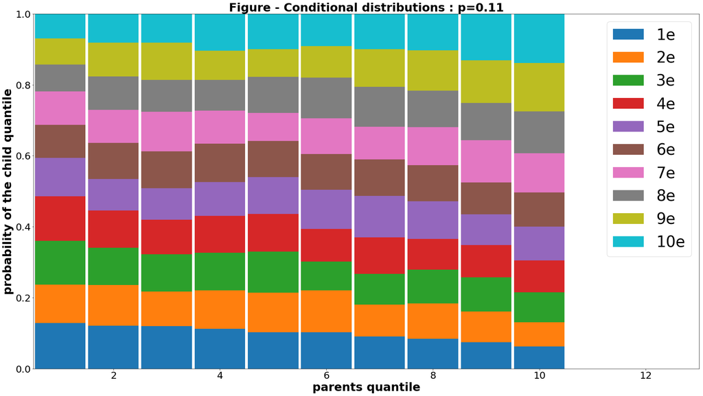

```python
country_plot_conditional_distributions('FIN')
```

For a country with a coefficient of elasticity of 0.1, mobility in terms of income class is very high. Graphically, it is noted that regardless of the parents' income class, being in a class number is almost equiprobable. The income class of the child is independent of the income class of the parents.

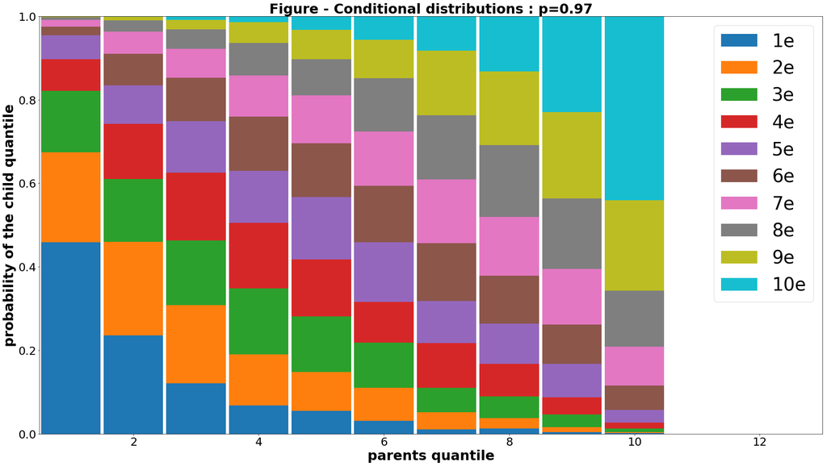

```python
country_plot_conditional_distributions('PAN')
```

For a country with a coefficient of elasticity of 0.9, mobility in terms of income class is very low. Graphically, we notice:

When the parents belong to the 1st quantile, the probability that the child remains in this quantile is 0.4, which is very high. In other words, there is a high probability that the child does not change the quantile and remains in that of his parents.

When the parents belong to the 10th quantile, the probability that the child remains in this quantile is 0.5, which is very high. In other words, there is a high probability that the child does not change the quantile and remains in that of his parents.

Between the 4th and 7th percentile, the odds of staying in the quantile of his parents, or of changing quantile ± 1, are similar.

### Removal

```python
del y_child, y_parents
```

### New sample : 1000 times bigger

```python
data_repeated = data[['country','quantile']]
data_repeated.columns = ['country','c_k_parent']
data_repeated = pd.concat([data_repeated]*1000, ignore_index=True)

# Initialization for children's income classes
data_repeated['c_k_child'] = 1

print('Size of the starting sample :',data.shape)
print('Size of the new sample :',data_repeated.shape)
```

```
Size of the starting sample : (11500, 11)
Size of the new sample : (11500000, 3)
```

We change the type of columns to optimize storage !

```python
data_repeated['country'] = data_repeated['country'].astype('category')
data_repeated['c_k_parent'] = data_repeated['c_k_parent'].astype('int8')
data_repeated['c_k_chil'] = data_repeated['c_k_child'].astype('int8')

data_repeated = data_repeated.sort_values(by=['country', 'c_k_child'],ascending=[True,True])
data_repeated.head()
```

|  | country | c_k_parent | c_k_child | c_k_chil |
| --- | --- | --- | --- | --- |
| 0 | ALB | 1 | 1 | 1 |
| 1 | ALB | 2 | 1 | 1 |
| 2 | ALB | 3 | 1 | 1 |
| 3 | ALB | 4 | 1 | 1 |
| 4 | ALB | 5 | 1 | 1 |

```python
coeff_elasticity = data[['country','IGEincome']].drop_duplicates()
coeff_elasticity = coeff_elasticity.set_index('country')
coeff_elasticity.head()
```

| country | IGEincome |
| --- | --- |
| ALB | 0.815874 |
| ARG | 0.660000 |
| ARM | 0.500000 |
| AUT | 0.245267 |
| AZE | 0.500000 |

### Conditional probability of each country written in a JSON file

```python
import json
import time
from IPython.display import clear_output

nb_quantiles = 100       # number of quantiles (number of income classes)
n  = 1000*nb_quantiles   # sample size

# Set to True if cell execution
calculate_conditional_distributions = False

# 600 seconds for the execution of the cell
if calculate_conditional_distributions :
    conditional_distributions = {}
    start_time = time.time()
    for i, row in enumerate(coeff_elasticite.iterrows()):
        iso3 = row[0]
        pj = row[1][0]
        clear_output(' ')
        print(f"""{time.time()-start_time:.2f}s - pays {i+1}/{len(coeff_elasticite)}""")
        y_child, y_parents = generate_incomes(n, pj)
        sample = compute_quantiles(y_child, y_parents, nb_quantiles)
        cd = conditional_distributions(sample, nb_quantiles)
        conditional_distributions[iso3] = cd.tolist()
        print("Calculation done")

    app_json = json.dumps(conditional_distributions, sort_keys=True)
    with open("fichier.json", "w") as f_write:
        json.dump(app_json, f_write)
    print('Dowloaded : format JSON.')
```

```python
# If the previous cell is not executed, read the conditional distributions from the Json file
with open("fichier.json", "r") as f_read:
    json_conditional_distributions = json.load(f_read)
json_conditional_distributions = json.loads(json_conditional_distributions)
```

### Attribution of children's income classes

```python
data_repeated.set_index(['country','c_k_parent'],inplace=True)
data_repeated.head()
```

| country | c_k_parent | c_k_child | c_k_chil |
| --- | --- | --- | --- |
| ALB | 1 | 1 | 1 |
|  | 2 | 1 | 1 |
|  | 3 | 1 | 1 |
|  | 4 | 1 | 1 |
|  | 5 | 1 | 1 |

```python
def repartition_class_children(n_quantile, frequences):
    c_k_children = []
    for i in range(len(frequences)):
        number_children_class_i = int(frequences[i]*n_quantile)
        c_k_children.extend([i+1]*number_children_class_i)
    return c_k_children
```

```python
# Set to True if executing the next cell
calculate_c_k_children = False
```

```python
# 460 seconds for the execution of the cell
if calculate_c_k_children:

    c_k_parents_values = np.arange(1,101, dtype='int8')
    c_k_children_values = np.arange(1,101, dtype='int8')

    start_time = time.time()

    # for each country
    for i, code_country in enumerate(data['country'].drop_duplicates().values):
        # coefficient of elasticity of the country
        pj = data.loc[data['country'] == code_country,'IGEincome']

        # progress display
        clear_output(' ')
        print(f"""{time.time()-start_time:.2f}s - country {i+1}/{len(coeff_elasticity)}""")

        # for each parent class c_k_parent
        for c_k_parent in c_k_parents_values:

            # we get the distribution of children classes
            dc = json_conditional_distributions[code_country][c_k_parent-1]
            # we calculate the values according to this distribution
            c_k_children = repartition_class_children(1000, dc)
            # it is assigned to the 1000 individuals of (country, c_k_parent) in progress
            data_repeated.loc[(code_country,c_k_parent), 'c_k_child'] = c_k_children

    # save
    data_repeated['c_k_child'] = data_repeated['c_k_child'].astype('int8')
    data_repeated = data_repeated.reset_index(level=['country','c_k_parent'])
    data_repeated.to_csv('data_repeated.csv')
    print("\n-> dist_inter_gen saved (format CSV)")
```

```python
data_repeated = pd.read_csv("data_repeated.csv",index_col=0)
```

```python
data_repeated.head()
```

|  | country | c_k_parent | c_k_enfant |
| --- | --- | --- | --- |
| 0 | ALB | 1 | 1 |
| 1 | ALB | 2 | 1 |
| 2 | ALB | 3 | 1 |
| 3 | ALB | 4 | 1 |
| 4 | ALB | 5 | 1 |

### Verification of distributions of children's income classes

```python
def verif_distrib(country_code,c_k_parent):
    country = data_repeated[data_repeated['country']==country_code]
    country_c_k_parent = country[country['c_k_parent']== c_k_parent]['c_k_enfant']
    plt.figure(figsize = (31, 17))
    plt.hist(country_c_k_parent, bins=100,label='Conditional distributions')
    plt.plot(np.arange(1,101),(pd.Series(json_conditional_distributions[country_code][c_k_parent-1])*1000).tolist(), label='Theorical Conditional distributions',linewidth=6)
    plt.xlabel('Class',fontsize=30,fontweight = 'bold')
    plt.ylabel('Number of individuals in the class',fontsize=30,fontweight = 'bold')
    plt.xticks(fontsize=25)
    plt.yticks(fontsize=25)
    plt.legend(loc='upper right',fontsize=30)
    plt.title('Figure 11 - Conditional distributions',fontsize=30,fontweight = 'bold')
    plt.savefig('figure/Figure 11 - Conditional distributions.png', dpi=300)
    plt.show()
```

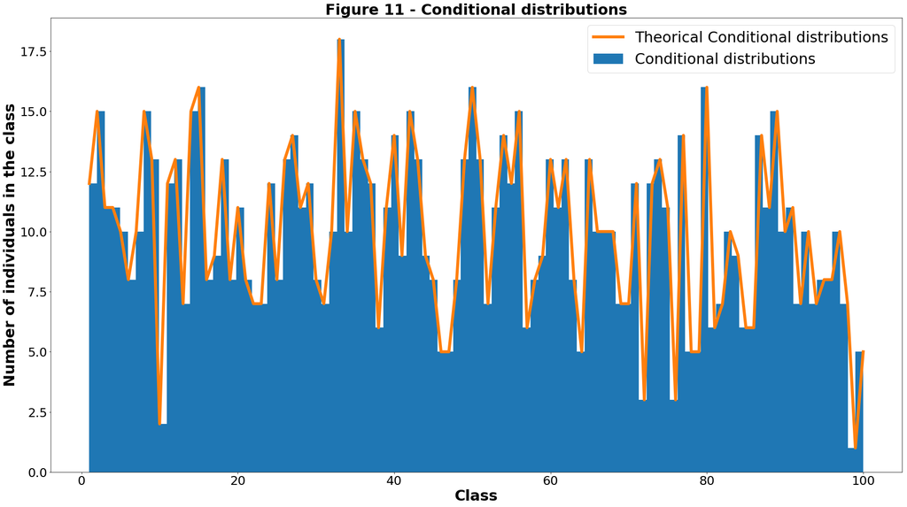

```python
verif_distrib('FRA',37)
```

Conditional distributions follow "theoretical conditional distributions".

### Attribution of children's income classes

```python
# country_quantile_income : Revenue per quantile per country
country_quantile_income = data[['country','quantile','income']]

# country_gdpppp_gini : Average income and Gini index by country
country_gdpppp_gini = data[['country','gdpppp','indice_gini']].drop_duplicates()

# Left join to have parents' income
final_data = pd.merge(data_repeated, country_quantile_income, how='left', left_on = ['country','c_k_parent'], right_on = ['country','quantile'])
final_data.drop('quantile', axis=1, inplace=True)
final_data.columns = ["country","c_k_parent","c_k_enfant","income_parent"]

# Left join to have children's income
final_data = pd.merge(final_data, country_quantile_income, how='left', left_on = ['country','c_k_enfant'], right_on = ['country','quantile'])
final_data.drop('c_k_enfant', axis=1, inplace=True)
final_data.drop('quantile', axis=1, inplace=True)
final_data.columns = ["country","c_k_parent","income_parent","income_child"]

# Jointure gauche pour avoir le revenu moyen et l'indice de Gini par pays
final_data = pd.merge(final_data, country_gdpppp_gini, how='left', left_on = ['country'], right_on = ['country'])
final_data.head()
```

|  | country | c_k_parent | income_parent | income_child | gdpppp | indice_gini |
| --- | --- | --- | --- | --- | --- | --- |
| 0 | ALB | 1 | 728.89795 | 728.89795 | 7297.0 | 30.0 |
| 1 | ALB | 2 | 916.66235 | 728.89795 | 7297.0 | 30.0 |
| 2 | ALB | 3 | 1010.91600 | 728.89795 | 7297.0 | 30.0 |
| 3 | ALB | 4 | 1086.90780 | 728.89795 | 7297.0 | 30.0 |
| 4 | ALB | 5 | 1132.69970 | 728.89795 | 7297.0 | 30.0 |